# Exploring Mental Health (MSU MSDS 6306 analysis Assignment 10 201803)

Luay Dajani

March 20, 2018

[figure not shown]

By Billy Hathorn - Own work, CC BY-SA 3.0, https://commons.wikimedia.org/w/index.php?curid=27271442

This and all relevant code can be found at: https://github.com/LuayD/SMU-MSDS/tree/master/Exploring_Mental_Health_6306_10

# VA Mental Health Clinics Analysis

VA hospitals are the very cruix of maintaining competitive, relevant, and continuing healthcare for the menand women who service this country.

## Purpose

(Mock) Organization’s purpose of this analysis is to determine which states or areas of the country may be underserved in order to draft a recommendation into where the most appropriate locations to plan for new VA hospitals.

## Part 1: Mental Health Clinics (Number Per State)

Analysis purpose here to import data as an RDA file directrly from a datasource, clean and prune the data, then start making use of the data. THe plot will show the number of VA hospitals per state and DC (though the VS data included the offshore territories, the analysis strips those out).

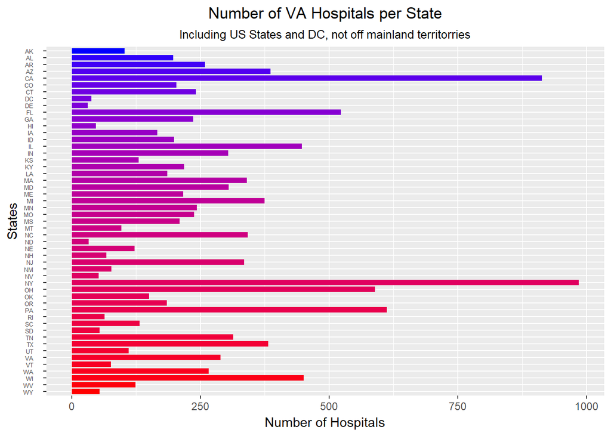

```r
### Analysis 1a: Load in environment data with SAMHDA

# Load in RDA file
str_RData_file <- "data/N-MHSS-2015-DS0001-data/N-MHSS-2015-DS0001-data-r.rda"
load(str_RData_file)

# Load in attributes fron column names for descriptive text
lst_data_attributes <- attr(mh2015_puf, "variable.labels")

### Analysis 1b: List the state abreviations represented in the data

library(plyr)
# Do a 2 de-reference to get the count in a DF then get the x column, then cast factor to character then dlee spaces
# taking out spaces from *ref1
vec_state_abbrev <- gsub(" ", "", as.character(count(mh2015_puf$LST)$x))

### Analysis 1c: Include listings of only states & DC (exclude offland terriories) from initial DF

# offland territories *ref2
vec_territory_abbrev <- c("AS", "FM", "GU", "MH", "MP", "PW", "PR", "VI")

# create count of states using filter deriving mainland states vector and number of centers,
# just find where the element does not match the filter of not wanted territories and use count *ref#3
dfm_VA_per_state <- count(mh2015_puf[!is.element(gsub(" ", "", as.character(mh2015_puf$LST)), vec_territory_abbrev),]$LST)
#change the colnames to something readable
colnames(dfm_VA_per_state) <- c("state", "number_va_hopitals")
#add column with orinal numbers to randomly color bars in subsequent plot
dfm_VA_per_state["color_code"] <- 1:length(dfm_VA_per_state$state)

### Analysis 1d: ggplot barchart of filtered dataset
library(ggplot2)
library(plyr)

# plot using bar and reordering so A-Z state abbrevs first *ref#4, also played with geor_bar colors *ref#5,
# also not showing legend *ref#6
ggplot(dfm_VA_per_state, aes(reorder(state, desc(state)), number_va_hopitals)) +
  geom_bar(stat="identity", aes(fill=color_code), width = .8, show.legend = FALSE) +
  coord_flip() + #flip graph
  ggtitle("Number of VA Hospitals per State" ,
          subtitle = "Including US States and DC, not off mainland territorries") +
  xlab("States") +
  ylab("Number of Hospitals") +
  scale_fill_gradient(low="blue", high="red") +
  theme(plot.title = element_text(hjust = 0.5),
        plot.subtitle = element_text(hjust = 0.5),
        axis.text.y = element_text(size = 5)
        )
```

## Part 2: Cleaning Data and Introducing new features

This part allows for the merging and basic operations on the data to allow a different view. The plot shows how many VA hospitals are available per thousand square mile, and an indication per defined region (Northeast, South, Midwest, and West). In this case the data will show that there is an interesting concentration of hopitals within a certain region.

```r
### Analysis 2a: Load in state information data and see issues with merging

# read in file data
str_state_data_file <- "data/statesize.csv"
dfm_state_data <- read.csv(str_state_data_file, stringsAsFactors = FALSE)
dfm_merged_VA_state_data <-  merge(x = dfm_VA_per_state, y = dfm_state_data, by.x = "state", by.y = "Abbrev")
# The abbreiations do not match as either one is a Factor or has etraneous spaces.  Will clean that out and concert to string
# show current merged state (empty)
head(dfm_merged_VA_state_data)
```

```
## [1] state              number_va_hopitals color_code
## [4] StateName          SqMiles            Region
## <0 rows> (or 0-length row.names)
```

```r
# show structure
str(dfm_VA_per_state)
```

```
## 'data.frame':    51 obs. of  3 variables:
##  $ state             : Factor w/ 55 levels "AK    ","AL    ",..: 1 2 3 5 6 7 8 9 10 11 ...
##  $ number_va_hopitals: int  103 197 259 386 913 203 241 38 31 523 ...
##  $ color_code        : int  1 2 3 4 5 6 7 8 9 10 ...
```

```r
### Analysis 2b: Fix issue and merge

# use gsub function to delete spaces and change to string (character)
dfm_VA_per_state$state <- gsub(" ", "", as.character(dfm_VA_per_state$state))
# re-show structure
str(dfm_VA_per_state)
```

```
## 'data.frame':    51 obs. of  3 variables:
##  $ state             : chr  "AK" "AL" "AR" "AZ" ...
##  $ number_va_hopitals: int  103 197 259 386 913 203 241 38 31 523 ...
##  $ color_code        : int  1 2 3 4 5 6 7 8 9 10 ...
```

```r
#re-merge
dfm_merged_VA_state_data <-  merge(x = dfm_VA_per_state, y = dfm_state_data, by.x = "state", by.y = "Abbrev")
# re-show current merged state
head(dfm_merged_VA_state_data)
```

```
##   state number_va_hopitals color_code  StateName SqMiles Region
## 1    AK                103          1     Alaska  570374   West
## 2    AL                197          2    Alabama   50750  South
## 3    AR                259          3   Arkansas   52075  South
## 4    AZ                386          4    Arizona  113642   West
## 5    CA                913          5 California  155973   West
## 6    CO                203          6   Colorado  103730   West
```

```r
### Analysis 2c: Calculate VA hospitals per square mile

# Add new variable (column) to the merged data frame showing the VA calculated hospitals per sq mile
dfm_merged_VA_state_data$HospitalsPerKSqMile <- dfm_merged_VA_state_data$number_va_hopitals / (dfm_merged_VA_state_data$SqMiles / 1000)
head(dfm_merged_VA_state_data)
```

```
##   state number_va_hopitals color_code  StateName SqMiles Region
## 1    AK                103          1     Alaska  570374   West
## 2    AL                197          2    Alabama   50750  South
## 3    AR                259          3   Arkansas   52075  South
## 4    AZ                386          4    Arizona  113642   West
## 5    CA                913          5 California  155973   West
## 6    CO                203          6   Colorado  103730   West
##   HospitalsPerKSqMile
## 1           0.1805833
## 2           3.8817734
## 3           4.9735958
## 4           3.3966315
## 5           5.8535772
## 6           1.9570038
```

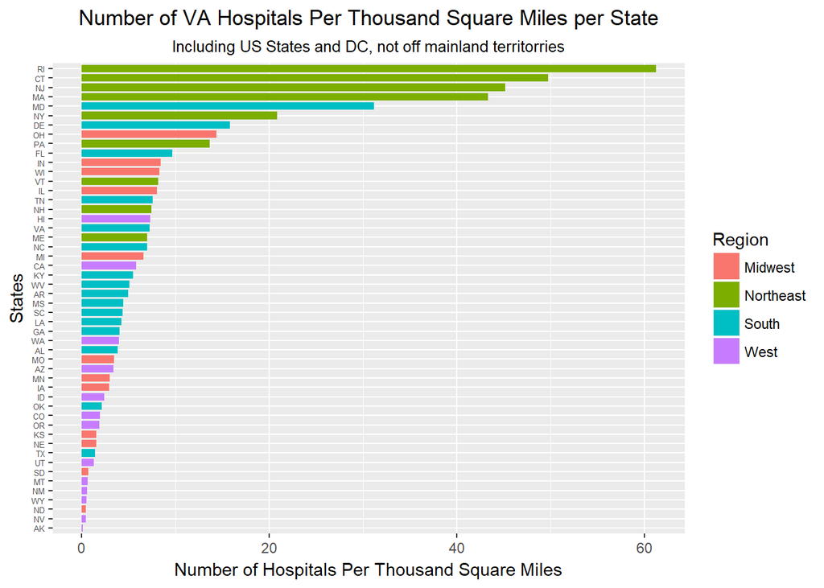

```r
### Analysis 2d: Plot VAs per square 1000 miles

# Copy plot info from 1d, reorder the bars to show by descending order from top and fil per region
ggplot(dfm_merged_VA_state_data, aes(reorder(state, HospitalsPerKSqMile), HospitalsPerKSqMile)) +
  geom_bar(stat="identity", aes(fill=Region), width = .8, show.legend = TRUE) +
  coord_flip() + #flip graph
  ggtitle("Number of VA Hospitals Per Thousand Square Miles per State" ,
          subtitle = "Including US States and DC, not off mainland territorries") +
  xlab("States") +
  ylab("Number of Hospitals Per Thousand Square Miles") +
  theme(plot.title = element_text(hjust = 0.5),
        plot.subtitle = element_text(hjust = 0.5),
        axis.text.y = element_text(size = 5)
  )
```

```r
### Analysis 2e: Analyse: patters, region distribution, Advice given
# See conclustion below:
```

[output not shown]

## Notes and Disclaimers:

Please note that data used in this analysis are from the Substance Abuse and Mental Health Data Archive, which is freely availailable at: https://datafiles.samhsa.gov/study-dataset/national-mental-health-services-survey-2015-n-mhss-2015-ds0001-nid17098 which are regulated by terms and conditions: https://www.datafiles.samhsa.gov/info/terms-use-nid3422. Disclaimer: Though this analysis is derived from real data, it is meant to be a mock assignment and hence is missing many other potential confouding and relevant variables, so not meant to endorse any paticular position.

## References from comments in the code and text:

##### 1: Remove spaces from text https://stackoverflow.com/questions/5992082/how-to-remove-all-whitespace-from-a-string

##### 2: US state & territory abbreviations: http://www.stateabbreviations.us/

##### 3: Remove a particular group of elements in a vector? https://stackoverflow.com/questions/11672227/remove-a-particular-group-of-elements-in-a-vector

##### 4: r - reverse order of discrete y axis in ggplot2 https://stackoverflow.com/questions/28391850/r-reverse-order-of-discrete-y-axis-in-ggplot2

##### 5: Fill gradient color not working with geom_bar of ggplot2 https://stackoverflow.com/questions/37343114/fill-gradient-color-not-working-with-geom-bar-of-ggplot2

##### 6: removing legend ggplot 2.2: https://stackoverflow.com/questions/35618260/removing-legend-ggplot-2-2

##### 7: History - VA History: https://www.va.gov/about_va/vahistory.asp

##### 8: What each state’s veteran population looks like, in 10 maps: https://www.washingtonpost.com/blogs/govbeat/wp/2014/11/11/what-each-states-veteran-population-looks-like-in-10-maps/?utm_term=.6d1e4b574b25